# 010

## Описание проекта

Сеть фитнес-центров «Культурист-датасаентист» разрабатывает стратегию взаимодействия с клиентами на основе аналитических данных.

Распространённая проблема фитнес-клубов и других сервисов — отток клиентов. Как понять, что клиент больше не с вами? Можно записать в отток тех, кто попросил закрыть договор или удалил аккаунт. Однако клиенты не всегда уходят демонстративно: чаще перестают пользоваться сервисом тихо.

Индикаторы оттока зависят от специфики отрасли. Когда пользователь редко, но стабильно закупается в интернет-магазине — не похоже, что он «отвалился». А вот если две недели не заходит на канал с ежедневно обновляемым контентом, дела плохи: подписчик заскучал и, кажется, оставил вас.

Для фитнес-центра можно считать, что клиент попал в отток, если за последний месяц ни разу не посетил спортзал. Конечно, не исключено, что он уехал на Бали и по приезде обязательно продолжит ходить на фитнес. Однако чаще бывает наоборот. Если клиент начал новую жизнь с понедельника, немного походил в спортзал, а потом пропал — скорее всего, он не вернётся.

Чтобы бороться с оттоком, отдел по работе с клиентами «Культуриста-датасаентиста» перевёл в электронный вид множество клиентских анкет. Ваша задача — провести анализ и подготовить план действий по удержанию клиентов, а именно:

- научиться прогнозировать вероятность оттока (на уровне следующего месяца) для каждого клиента;
- сформировать типичные портреты клиентов: выделить несколько наиболее ярких групп и охарактеризовать их основные свойства;
- проанализировать основные признаки, наиболее сильно влияющие на отток;
- сформулировать основные выводы и разработать рекомендации по повышению качества работы с клиентами:
  - 1) выделить целевые группы клиентов;
  - 2) предложить меры по снижению оттока;
  - 3) определить другие особенности взаимодействия с клиентами.

## Инструкция по выполнению проекта

### Шаг №1. Загрузите данные и подготовьте их к анализу

«Культурист-датасаентист» предоставил сведения в csv-файлах. Заказчик подготовил данные, которые содержат данные на месяц до оттока и факт оттока на определённый месяц. Набор данных включает следующие поля:

- Данные клиента за предыдущий до проверки факта оттока месяц:
  - 'gender' — пол;
  - 'Near_Location' — проживание или работа в районе, где находится фитнес-центр;
  - 'Partner' — сотрудник компании-партнёра клуба (сотрудничество с компаниями, чьи сотрудники могут получать скидки на абонемент — в таком случае фитнес-центр хранит информацию о работодателе клиента);
  - Promo_friends — факт первоначальной записи в рамках акции «приведи друга» (использовал промо-код от знакомого при оплате первого абонемента);
  - 'Phone' — наличие контактного телефона;
  - 'Age' — возраст;
  - 'Lifetime' — время с момента первого обращения в фитнес-центр (в месяцах).
- Информация на основе журнала посещений, покупок и информация о текущем статусе абонемента клиента:
  - 'Contract_period' — длительность текущего действующего абонемента (месяц, 6 месяцев, год);
  - 'Month_to_end_contract' — срок до окончания текущего действующего абонемента (в месяцах);
  - 'Group_visits' — факт посещения групповых занятий;
  - 'Avg_class_frequency_total' — средняя частота посещений в неделю за все время с начала действия абонемента;
  - 'Avg_class_frequency_current_month' — средняя частота посещений в неделю за предыдущий месяц;
  - 'Avg_additional_charges_total' — суммарная выручка от других услуг фитнес-центра: кафе, спорттовары, косметический и массажный салон.
- 'Churn' — факт оттока в текущем месяце.

### Шаг 2. Проведите исследовательский анализ данных (EDA)

- Посмотрите на датасет: есть ли в нем отсутствующие признаки, изучите средние значения и стандартные отклонения (пригодится метод describe());
- Посмотрите на средние значения признаков в двух группах — тех, кто ушел в отток и тех, кто остался (воспользуйтесь методом groupby());
- Постройте столбчатые гистограммы и распределения признаков для тех, кто ушёл (отток) и тех, кто остался (не попали в отток);
- Постройте матрицу корреляций и отобразите её.

### Шаг 3. Постройте модель прогнозирования оттока клиентов

- Разбейте данные на обучающую и валидационную выборку функцией train_test_split().
- Обучите модель на train-выборке двумя способами:
  - логистической регрессией,
  - случайным лесом.
- Оцените метрики accuracy, precision и recall для обеих моделей на валидационной выборке. Сравните по ним модели. Какая модель показала себя лучше на основании метрик?

Не забудьте указать параметр random_state при разделении выборки и задании алгоритма.

### Шаг 4. Сделайте кластеризацию клиентов

Отложите в сторону столбец с оттоком и проведите кластеризацию объектов (клиентов):

- Стандартизируйте данные.
- Постройте матрицу расстояний функцией linkage() на стандартизованной матрице признаков и нарисуйте дендрограмму. Внимание: отрисовка дендрограммы может занять время! На основании полученного графика предположите, какое количество кластеров можно выделить.
- Обучите модель кластеризации на основании алгоритма K-Means и спрогнозируйте кластеры клиентов. Договоримся за число кластеров принять n=5, чтобы ваши результаты можно было сравнивать с результатами остальных студентов. Однако, конечно, в жизни никто не скажет вам правильный ответ, и решение остаётся за вами (на основании изучения графика из предыдущего пункта).
- Посмотрите на средние значения признаков для кластеров. Можно ли сразу что-то заметить?
- Постройте распределения признаков для кластеров. Можно ли что-то заметить по ним?
- Для каждого полученного кластера посчитайте долю оттока (методом groupby()). Отличаются ли они по доле оттока? Какие кластеры склонны к оттоку, а какие — надёжны?

### Шаг 5. Сформулируйте выводы и сделайте базовые рекомендации по работе с клиентами

Сформулируйте основные выводы и предложите рекомендации для стратегии взаимодействия с клиентами и их удержания.  
Не описывайте стратегию детально: достаточно 3-4 важных принципов и примеров их реализации в виде определённых маркетинговых действий.

# Содержание

### Загрузка и подготовка данных к анализу

#### Загрузим данные

```python
import pandas as pd
import seaborn as sns
import matplotlib.pyplot as plt
```

```python
from sklearn.model_selection import train_test_split
from sklearn.linear_model import LogisticRegression
from sklearn.ensemble import RandomForestClassifier
from sklearn.metrics import accuracy_score, precision_score, recall_score
from sklearn.preprocessing import StandardScaler
from scipy.cluster.hierarchy import dendrogram, linkage
from sklearn.cluster import KMeans
```

```python
pd.options.display.float_format = '{:,.2f}'.format
```

```python
try:
    df = pd.read_csv('/datasets/gym_churn.csv')
except:
    print('Ошибка подгрузки данных')
```

```python
df.info()
```

```
<class 'pandas.core.frame.DataFrame'>
RangeIndex: 4000 entries, 0 to 3999
Data columns (total 14 columns):
 #   Column                             Non-Null Count  Dtype
---  ------                             --------------  -----
 0   gender                             4000 non-null   int64
 1   Near_Location                      4000 non-null   int64
 2   Partner                            4000 non-null   int64
 3   Promo_friends                      4000 non-null   int64
 4   Phone                              4000 non-null   int64
 5   Contract_period                    4000 non-null   int64
 6   Group_visits                       4000 non-null   int64
 7   Age                                4000 non-null   int64
 8   Avg_additional_charges_total       4000 non-null   float64
 9   Month_to_end_contract              4000 non-null   float64
 10  Lifetime                           4000 non-null   int64
 11  Avg_class_frequency_total          4000 non-null   float64
 12  Avg_class_frequency_current_month  4000 non-null   float64
 13  Churn                              4000 non-null   int64
dtypes: float64(4), int64(10)
memory usage: 437.6 KB
```

```python
df.sample(5)
```

|  | gender | Near_Location | Partner | Promo_friends | Phone | Contract_period | Group_visits | Age | Avg_additional_charges_total | Month_to_end_contract | Lifetime | Avg_class_frequency_total | Avg_class_frequency_current_month | Churn |
| --- | --- | --- | --- | --- | --- | --- | --- | --- | --- | --- | --- | --- | --- | --- |
| 2141 | 0 | 1 | 0 | 0 | 1 | 1 | 0 | 30 | 320.48 | 1.00 | 5 | 1.70 | 1.66 | 0 |
| 3094 | 1 | 1 | 0 | 0 | 1 | 1 | 0 | 21 | 258.06 | 1.00 | 0 | 1.37 | 1.20 | 1 |
| 6 | 1 | 1 | 1 | 1 | 0 | 6 | 1 | 32 | 94.27 | 6.00 | 2 | 1.14 | 1.28 | 0 |
| 2217 | 0 | 1 | 0 | 0 | 1 | 1 | 1 | 24 | 31.94 | 1.00 | 3 | 1.62 | 0.93 | 1 |
| 98 | 1 | 1 | 0 | 0 | 1 | 1 | 0 | 26 | 125.39 | 1.00 | 0 | 1.38 | 0.27 | 1 |

#### Приведение названия столбцов к нижнему регистру

```python
df.columns = df.columns.str.lower()
df.columns
```

```
Index(['gender', 'near_location', 'partner', 'promo_friends', 'phone',
       'contract_period', 'group_visits', 'age',
       'avg_additional_charges_total', 'month_to_end_contract', 'lifetime',
       'avg_class_frequency_total', 'avg_class_frequency_current_month',
       'churn'],
      dtype='object')
```

#### Стобцы gender, near_location, partner, promo_friends, phone, group_visits, churn

```python
df.gender.value_counts()
```

```
1    2041
0    1959
Name: gender, dtype: int64
```

```python
df.near_location.value_counts()
```

```
1    3381
0     619
Name: near_location, dtype: int64
```

```python
df.partner.value_counts()
```

```
0    2053
1    1947
Name: partner, dtype: int64
```

```python
df.promo_friends.value_counts()
```

```
0    2766
1    1234
Name: promo_friends, dtype: int64
```

```python
df.phone.value_counts()
```

```
1    3614
0     386
Name: phone, dtype: int64
```

```python
df.group_visits.value_counts()
```

```
0    2351
1    1649
Name: group_visits, dtype: int64
```

```python
df.churn.value_counts()
```

```
0    2939
1    1061
Name: churn, dtype: int64
```

Данные корректны

#### Столбец contract_period

```python
df.contract_period.value_counts()
```

```
1     2207
12     960
6      833
Name: contract_period, dtype: int64
```

Данные корректны

#### Столбец age

```python
df.age.value_counts()
```

```
29    468
30    457
28    447
31    434
27    378
32    364
26    300
33    253
25    231
34    174
24    148
35     98
23     82
36     48
22     33
37     29
21     24
20     14
38     10
39      3
18      2
19      2
41      1
Name: age, dtype: int64
```

Данные корректны

#### Столбцы avg_additional_charges_total, avg_class_frequency_total, avg_class_frequency_current_month

```python
df.avg_additional_charges_total.describe().loc[['min','max']]
```

```
min     0.15
max   552.59
Name: avg_additional_charges_total, dtype: float64
```

```python
df.avg_class_frequency_total.describe().loc[['min','max']]
```

```
min   0.00
max   6.02
Name: avg_class_frequency_total, dtype: float64
```

```python
df.avg_class_frequency_current_month.describe().loc[['min','max']]
```

```
min   0.00
max   6.15
Name: avg_class_frequency_current_month, dtype: float64
```

Данные корректны

#### Столбец month_to_end_contract

```python
df.month_to_end_contract.value_counts()
```

```
1.00     2207
6.00      645
12.00     524
11.00     181
5.00      130
10.00      82
9.00       73
4.00       58
8.00       38
7.00       25
3.00       23
2.00       14
Name: month_to_end_contract, dtype: int64
```

Данные корректны, только поменяем тип данных на целочисленный

```python
df.month_to_end_contract = df.month_to_end_contract.astype('int64')
df.month_to_end_contract.value_counts()
```

```
1     2207
6      645
12     524
11     181
5      130
10      82
9       73
4       58
8       38
7       25
3       23
2       14
Name: month_to_end_contract, dtype: int64
```

#### Столбец lifetime

```python
df.lifetime.value_counts()
```

```
1     843
2     610
3     490
0     487
4     383
5     273
6     220
7     167
8     111
9     100
10     76
12     53
11     48
13     28
15     24
14     24
16     15
17     11
19      7
18      7
20      7
21      5
26      2
24      2
22      2
23      2
27      1
29      1
31      1
Name: lifetime, dtype: int64
```

Данные корректны

#### Проверка на дубликаты

```python
df.duplicated().sum()
```

```
0
```

#### Вывод

- Названия столбцов привели к строчному виду;
- Столбцу month_to_end_contract изменили тип данных на целочисленный;
- Данные проверили на корректность, пропуски и дубликаты

### Исследовательский анализ данных

#### Средние значения и стандартные отклонения

```python
df.describe().loc[['mean','std', '50%']]
```

|  | gender | near_location | partner | promo_friends | phone | contract_period | group_visits | age | avg_additional_charges_total | month_to_end_contract | lifetime | avg_class_frequency_total | avg_class_frequency_current_month | churn |
| --- | --- | --- | --- | --- | --- | --- | --- | --- | --- | --- | --- | --- | --- | --- |
| mean | 0.51 | 0.85 | 0.49 | 0.31 | 0.90 | 4.68 | 0.41 | 29.18 | 146.94 | 4.32 | 3.72 | 1.88 | 1.77 | 0.27 |
| std | 0.50 | 0.36 | 0.50 | 0.46 | 0.30 | 4.55 | 0.49 | 3.26 | 96.36 | 4.19 | 3.75 | 0.97 | 1.05 | 0.44 |
| 50% | 1.00 | 1.00 | 0.00 | 0.00 | 1.00 | 1.00 | 0.00 | 29.00 | 136.22 | 1.00 | 3.00 | 1.83 | 1.72 | 0.00 |

##### Вывод

- Мужчин и женщин почти поровну;
- 85% клиентов живет или работает рядом с фитнес-центром, что вполне логично;
- Половина имеет скидку через "компанию-парнера" фитнес-центра;
- 31% оплатили первый абонемент через промо "приведи друга";
- 10% не указали свой телефон
- 55% имеют абонемент на месяц, 25% на год, 20% на полгода;
- 41% посещали групповые занятия;
- 29 лет - средний возраст, большая часть посетителей находится в возрасте от 26-ти до 32-х лет;
- В среднем клиент тратит на другие услуги фитнес-центра 146.94, медиана - 136.22;
- У 55% абонемент закончится через месяц, у 16% через 6 месяцев, у 13% через год;
- 3 месяца - среднее время с момента первого обращения в фитнес-центр;
- В среднем клиенты посещают центр почти 2 раза в неделю (1.83);
- За предыдущийй месяц посещаемость в неделю чуть упала - 1.72;
- 27% пользователей перестали ходить в фитнес-центр за текущий месяц

#### Средние значения признаков в двух группах — тех, кто ушел в отток и тех, кто остался

```python
mean_churn = df.groupby('churn').mean().T.reset_index()
mean_churn.columns = ['','in', 'out']
mean_churn
```

|  |  | in | out |
| --- | --- | --- | --- |
| 0 | gender | 0.51 | 0.51 |
| 1 | near_location | 0.87 | 0.77 |
| 2 | partner | 0.53 | 0.36 |
| 3 | promo_friends | 0.35 | 0.18 |
| 4 | phone | 0.90 | 0.90 |
| 5 | contract_period | 5.75 | 1.73 |
| 6 | group_visits | 0.46 | 0.27 |
| 7 | age | 29.98 | 26.99 |
| 8 | avg_additional_charges_total | 158.45 | 115.08 |
| 9 | month_to_end_contract | 5.28 | 1.66 |
| 10 | lifetime | 4.71 | 0.99 |
| 11 | avg_class_frequency_total | 2.02 | 1.47 |
| 12 | avg_class_frequency_current_month | 2.03 | 1.04 |

##### Вывод

- Пол не влияет на отток клиентов;
- В оттоке (0.77 на 0.87) больше тех кто живет или работает не рядом с клубом;
- Сотрудники компании-партнера более лояльны к клубу, чем "обычные" клиенты (0.53 на 0.36);
- Воспользовавшихся акцией "приведи друга" больше в 2 раза среди оставшихся, чем в оттоке (0.35 на 0.18);
- Указанный телефон не влияет на отток клиетов;
- У клиентов продолжающих посещать клуб средний срок текущего абонемента существенно больше, чем у покинувших (5.75 на 1.73);
- Групповые занятия повышают лояльность клиентов (0.46 на 0.27);
- Средний возраст в оттоке 27 лет, у оставшихся 30;
- Средний чек на допы в оттоке 115.1, у оставшихся 158.5;
- У покинувших клуб средняя продолжительность оставшего абонемента 1.66, у оставшихся 5.28;
- В оттоке среднее время с момента первого обращения - месяц, у тех кто продолжает посещать клуб почти 5-ть;
- Те кто продолжает, ходят в среднем по 2 раза в неделю, а кто бросил всего 1.5 раза;
- В предыдущем месяце, те кто продолжает заниматься ходили в среднем по 2 раза в неделю, а кто ушел в отток только 1 раз;

#### Визуализация анализа, гистограммы и распределения

Построим гистограммы для категориальных параметров

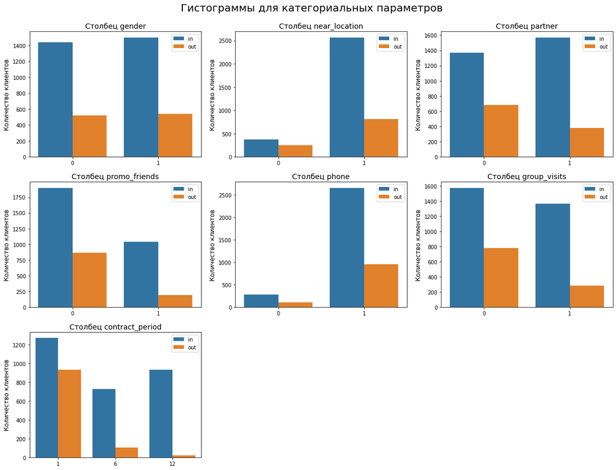

```python
list_cat = ['gender', 'near_location', 'partner', 'promo_friends', 'phone', 'group_visits', 'contract_period']
ncols = 3
nrows = len(list_cat) // ncols + (len(list_cat) % ncols > 0)
plt.figure(figsize=(20, 15))
plt.subplots_adjust(hspace=0.2)
plt.suptitle("Гистограммы для категориальных параметров", fontsize=20, y=.93)
for n, column in enumerate(list_cat):
    ax = plt.subplot(nrows, ncols, n + 1)
    sns.countplot(x = column, data=df, hue='churn')
    plt.title('Столбец ' + column, fontsize=14)
    plt.legend(['in','out'], fontsize=10)
    plt.xticks(fontsize=10)
    plt.yticks(fontsize=10)
    plt.xlabel('',fontsize=12)
    plt.ylabel('Количество клиентов', fontsize=12);
```

- gender - не влияет на отток пользователей;
- near_location - люди, которым дольше добираться до фитнеса бросают его чаще, чем люди которые живут или работают рядом с центром;
- partner - наличие скидки от "партнера" удерживает клиентов лучше, чем ее отсутствие;
- promo_friends - скидка от "друга" также помогает людям продолжать посещать фитнес;
- phone - не влияет на отток пользователей;
- group_visits - совместные занятия спортом, даже с незнакомыми людьми, положительно сказываются на желание человека продолжать заниматься;
- contract_period - чем больше заплатил, тем сильнее желание продолжать

Для числовых параметров построим диаграмму размаха

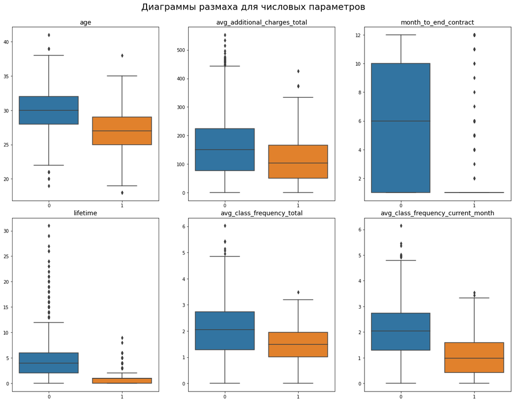

```python
list_num = ['age', 'avg_additional_charges_total', 'month_to_end_contract', 'lifetime', 'avg_class_frequency_total', 'avg_class_frequency_current_month']
ncols = 3
nrows = len(list_num) // ncols + (len(list_num) % ncols > 0)
plt.figure(figsize=(20, 15))
plt.subplots_adjust(hspace=0.1)
plt.suptitle("Диаграммы размаха для числовых параметров", fontsize=20, y=.93)
for n, column in enumerate(list_num):
    ax = plt.subplot(nrows, ncols, n + 1)
    sns.boxplot(x = 'churn', y = column, data=df)
    plt.title(column, fontsize=14)
    plt.xticks(fontsize=10)
    plt.yticks(fontsize=10)
    plt.xlabel('', fontsize=12)
    plt.ylabel('', fontsize=12);
```

- age - наиболее часто встречающийся возраст людей в оттоке 26-28 лет;
- avg_additional_charges_total - средние затраты на доп-услуги у ушедший клиентов составили 115;
- month_to_end_contract - средний срок остатка абонемента у пользователей в оттоке 1.7 месяца;
- lifetime - среднее время "общения с клубом" у ушедших людей один месяц;
- avg_class_frequency_total - ушедшие клиенты пользовались центром в среднем 1.5 раза в неделю;
- avg_class_frequency_current_month - в последний месяц перед уходом, человек ходит на фитнес в среднем один раз в неделю

#### Матрица корреляций

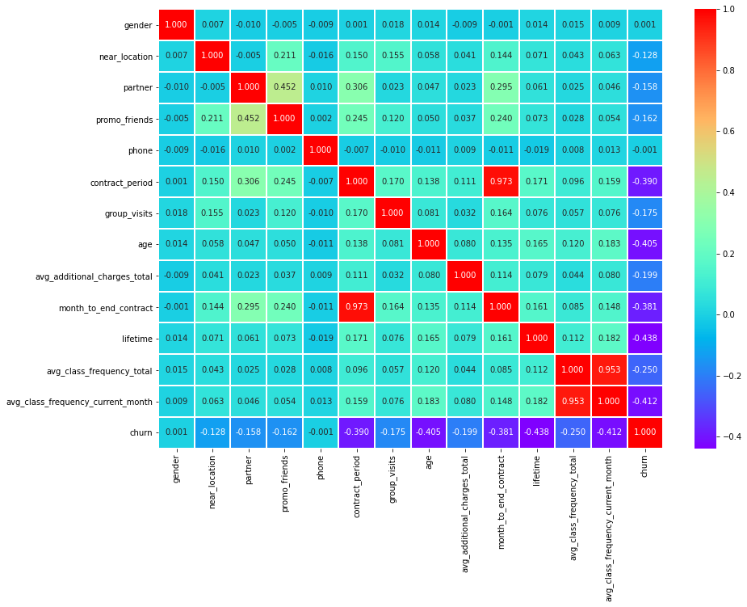

```python
matrix_corr = df.corr()
plt.figure(figsize=(14, 10))
sns.heatmap(matrix_corr , annot = True, linewidths=1, fmt = '0.3f', cmap="rainbow")
plt.show()
```

- Сильная корреляция между параметрами contract_period и month_to_end_contract, avg_class_frequency_total и avg_class_frequency_current_month, это неудивительно поскольку они зависят друг от друга;
- Корреляция между параметрами partner и promo_friends, указывает на то, что клиенты клуба по "скидочной партнерской программе" часто приводят друзей или знакомых, которые используют промокод promo_friends;
- Из матрицы еще раз видно, что параметры gender и phone не влияют на отток;
- Параметры - lifetime, avg_class_frequency_current_month, age и contract_period имеют самую сильное корреляцию с оттоком

### Построение модели прогнозирования оттока клиентов

Построим модель бинарной классификации клиентов, где целевой признак — факт оттока клиента в следующем месяце

#### Разделение данных на обучающую и валидационную выборку функцией train_test_split()

Разделим данные на признаки (матрица X) и целевую переменную (y)

```python
X = df.drop('churn', axis=1)
y = df.churn
```

Разделяем модель на обучающую и валидационную выборку, с атрибутами random_state=0 для генерации одних и тех же псевдослучайных величин и stratify=y для сохранения указанного нами соотношения (20%) значений нужного нам количества классов в целевой переменной

```python
X_train, X_test, y_train, y_test = train_test_split(X, y, test_size = 0.2, random_state=0, stratify=y)
```

#### Обучим модель на train-выборке: "логистической регрессией" и "случайным лесом"

##### Логистическая регрессия

Зададим алгоритм для модели логистической регрессии

```python
lr_model = LogisticRegression(random_state=0, solver='liblinear')
```

Обучим модель

```python
lr_model.fit(X_train, y_train)
```

```
LogisticRegression(random_state=0, solver='liblinear')
```

Воспользуемся уже обученной моделью, чтобы сделать прогноз

```python
lr_predictions = lr_model.predict(X_test)
```

##### Случайный лес

Зададим алгоритм для новой модели на основе алгоритма случайного леса

```python
rf_model = RandomForestClassifier(n_estimators = 100, random_state = 0)
```

Обучим модель случайного леса

```python
rf_model.fit(X_train, y_train)
```

```
RandomForestClassifier(random_state=0)
```

Воспользуемся уже обученной моделью, чтобы сделать прогноз

```python
rf_predictions = rf_model.predict(X_test)
```

#### Оценка метрик accuracy, precision и recall для обеих моделей на валидационной выборке

Создадим функцию, которая будет выводить наши метрики

```python
def print_all_metrics(y_true, y_pred, title='Метрики классификации'):
    print(title)
    print('\tAccuracy: {:.3f}'.format(accuracy_score(y_true, y_pred)))
    print('\tPrecision: {:.3f}'.format(precision_score(y_true, y_pred)))
    print('\tRecall: {:.3f}'.format(recall_score(y_true, y_pred)))
```

Выведем метрики для логистической регрессии

```python
print_all_metrics(y_test, lr_predictions, 'Метрики для логистической регрессии')
```

```
Метрики для логистической регрессии
	Accuracy: 0.931
	Precision: 0.894
	Recall: 0.840
```

Выведем метрики для случайного леса

```python
print_all_metrics(y_test, rf_predictions, 'Метрики для случайного леса')
```

```
Метрики для случайного леса
	Accuracy: 0.922
	Precision: 0.875
	Recall: 0.825
```

#### Вывод

- Обе модели показали общую точность более 90%, что является хорошим результатом;
- Показатели Precision и Recall чуть лучше у модели логистическая регрессия

### Кластеризация клиентов

#### Стандартизация данных, построение матрицы расстояний, дендрограмма

```python
sc = StandardScaler()
X_sc = sc.fit_transform(X)
linked = linkage(X_sc, method = 'ward')
```

Строим дендрограмму

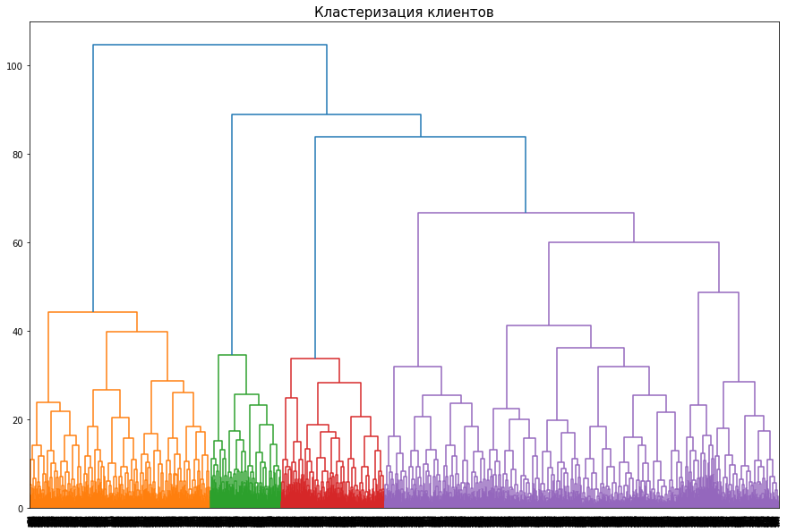

```python
plt.figure(figsize=(15, 10))
dendrogram(linked, orientation = 'top')
plt.title('Кластеризация клиентов', fontsize = 15);
```

На графике можно выделить от 4-х до 6-ти кластеров

#### Кластеризация на основании алгоритма K-Means

Зададим модель k_means с числом кластеров 5

```python
km = KMeans(n_clusters=5, random_state=0)
```

Применяем алгоритм к данным и формируем вектор кластеров

```python
labels = km.fit_predict(X_sc)
```

Сохраняем вектор кластеров

```python
df['cluster'] = labels
```

#### Изучение средних значений признаков для кластеров

Посмотрим количество пользователей в каждом кластере

```python
df.cluster.value_counts()
```

```
3    1262
0    1010
4     838
2     505
1     385
Name: cluster, dtype: int64
```

Выведем средние значения для каждого кластера

```python
cluster_features = df.groupby('cluster').mean().T
cluster_features.style.format('{:.2f}') \
                      .highlight_max(color='hotpink', axis=1) \
                      .highlight_min(color='skyblue', axis=1)
```

| cluster | 0 | 1 | 2 | 3 | 4 |
| --- | --- | --- | --- | --- | --- |
| gender | 0.50 | 0.52 | 0.50 | 0.49 | 0.56 |
| near_location | 0.96 | 0.86 | 0.00 | 1.00 | 0.98 |
| partner | 0.78 | 0.47 | 0.46 | 0.35 | 0.36 |
| promo_friends | 0.57 | 0.31 | 0.08 | 0.24 | 0.23 |
| phone | 1.00 | 0.00 | 1.00 | 1.00 | 1.00 |
| contract_period | 10.89 | 4.79 | 2.35 | 1.95 | 2.67 |
| group_visits | 0.54 | 0.43 | 0.22 | 0.34 | 0.47 |
| age | 29.98 | 29.30 | 28.48 | 28.17 | 30.13 |
| avg_additional_charges_total | 160.76 | 143.96 | 135.46 | 131.62 | 161.66 |
| month_to_end_contract | 9.95 | 4.48 | 2.20 | 1.86 | 2.46 |
| lifetime | 4.74 | 3.92 | 2.81 | 2.44 | 4.90 |
| avg_class_frequency_total | 1.98 | 1.85 | 1.66 | 1.25 | 2.85 |
| avg_class_frequency_current_month | 1.97 | 1.72 | 1.48 | 1.01 | 2.85 |
| churn | 0.03 | 0.27 | 0.44 | 0.51 | 0.07 |

**Кластер 0**, клиентов - 1010  
Cамые высокие параметры:  
-partner  
-promo_friends  
-contract_period  
-group_visits  
-month_to_end_contract

Самый низкий параметр:  
-churn

**Кластер 1**, клиентов - 385  
Самый низкий параметр:  
-phone

**Кластер 2**, клиентов - 505  
Cамые низкие параметры:  
-near_location  
-promo_friends  
-group_visits

**Кластер 3**, клиентов - 1262  
Cамые высокие параметры:  
-near_location  
-churn

Cамые низкие параметры:  
-partner  
-contract_period  
-month_to_end_contract  
-lifetime  
-avg_class_frequency_total  
-avg_class_frequency_current_month

**Кластер 4**, клиентов - 838  
Cамые высокие параметры:  
-gender  
-age  
-avg_additional_charges_total  
-lifetime  
-avg_class_frequency_total  
-avg_class_frequency_current_month

- Доля оттока в 0-ом и 4-ом кластере самая низкая, также в этих кластерах самые высокие параметры: lifetime, avg_additional_charges_total, group_visits;
- Доля оттока во 2-ом и 3-ем кластере самая высокая, а параметры: lifetime, avg_additional_charges_total, contract_period, month_to_end_contract, avg_class_frequency_total, avg_class_frequency_current_month и age самые низкие;
- Клиенты 1-го кластера не оставляют свой телефон, зато остальные параметры сопоставимые со средними параметрами всего датасета, при этом численная доля кластера меньше 10%;
- Размер 0-ого и 4-го кластера в сумме сопоставим с суммой размеров 2-ого и 3-его и составляет примерно 45%

#### Изучение распределения признаков для кластеров

Построим гистограммы для категориальных параметров

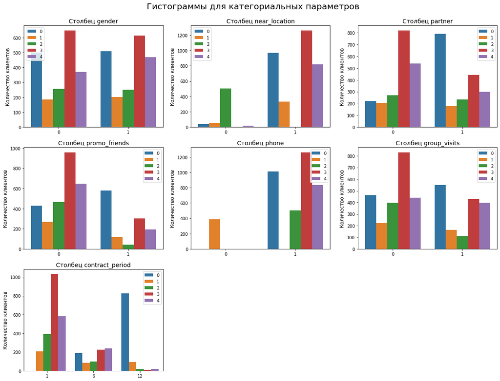

```python
list_cat = ['gender', 'near_location', 'partner', 'promo_friends', 'phone', 'group_visits', 'contract_period']
ncols = 3
nrows = len(list_cat) // ncols + (len(list_cat) % ncols > 0)
plt.figure(figsize=(20, 15))
plt.subplots_adjust(hspace=0.2)
plt.suptitle("Гистограммы для категориальных параметров", fontsize=20, y=.93)
for n, column in enumerate(list_cat):
    ax = plt.subplot(nrows, ncols, n + 1)
    sns.countplot(x = column, data=df, hue='cluster')
    plt.title('Столбец ' + column, fontsize=14)
    plt.legend(fontsize=10)
    plt.xticks(fontsize=10)
    plt.yticks(fontsize=10)
    plt.xlabel('',fontsize=12)
    plt.ylabel('Количество клиентов', fontsize=12);
```

Диаграммы размаха для числовых параметров

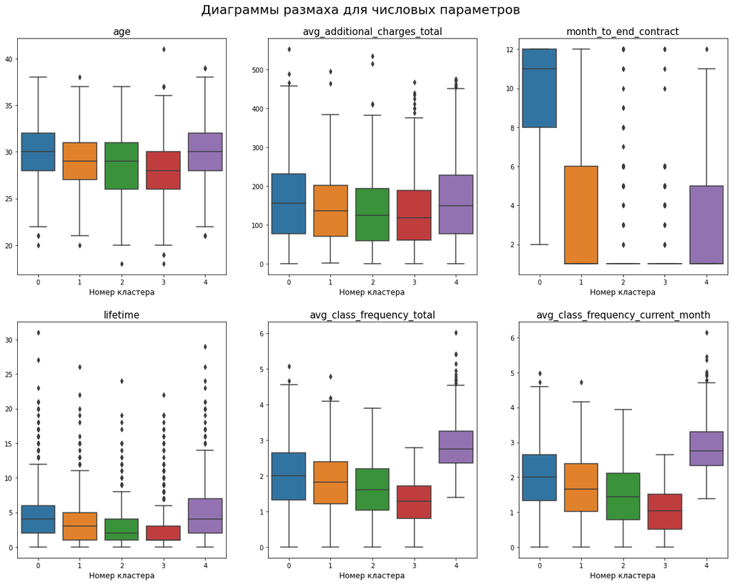

```python
list_num = ['age', 'avg_additional_charges_total', 'month_to_end_contract', 'lifetime', 'avg_class_frequency_total', 'avg_class_frequency_current_month']
ncols = 3
nrows = len(list_num) // ncols + (len(list_num) % ncols > 0)
plt.figure(figsize=(20, 15))
plt.subplots_adjust(hspace=0.2)
plt.suptitle("Диаграммы размаха для числовых параметров", fontsize=20, y=.93)
for n, column in enumerate(list_num):
    ax = plt.subplot(nrows, ncols, n + 1)
    sns.boxplot(x = 'cluster', y = column, data=df)
    plt.title(column, fontsize=15)
    plt.xticks(fontsize=10)
    plt.yticks(fontsize=10)
    plt.xlabel('Номер кластера', fontsize=12)
    plt.ylabel('', fontsize=12);
```

- age - разница между максимальным (кластер 4) и минимальным (кластер 3) средним возрастом меньше 2-х лет;
- avg_additional_charges_total - в 4-ом и 0-ом кластере средний доход от допов 162 и 161, во 2-м и 3-ем кластерах 135 и 132 соответственно;
- month_to_end_contract - в 0-ом кластере у клиентов в среднем 10 месяцев до конца абонемента, в 3-ем меньше 2-х месяцев;
- lifetime - лучший кластер по этому показателю 4-ый (4.9 месяца), 3-ий кластер в 2 раза хуже (2.44 месяца);
- avg_class_frequency_total - клиенты из 4-ого кластера ходят в клуб почти 3 раза в неделю, а клиенты из 3-го чуть больше одного раза;
- avg_class_frequency_current_month - в предыдущем месяце посещаемость фитнеса у пользователей из 4-го кластера осталась равной средней - почти 3 раза в неделю, а у пользователей из 3-его упала еще - до 1-го раза в неделю

#### Доля оттока для каждого кластера

```python
df.groupby('cluster').agg({'churn':'mean', 'gender':'count'}).sort_values(by='churn')
```

| cluster | churn | gender |
| --- | --- | --- |
| 0 | 0.03 | 1010 |
| 4 | 0.07 | 838 |
| 1 | 0.27 | 385 |
| 2 | 0.44 | 505 |
| 3 | 0.51 | 1262 |

### Общий вывод

- В датасете 4000 строк, данные проверены на пропуски и дубликаты, где необходимо измененны типы данных, наименования столбцов приведены к нижнему регистру;
- Рассчитаны общие средние значения параметров, средние значения параметров в двух группах (те кто остался и отток), а также матрица корреляций Пирсона; полученные данные визуализированны;
- Построенна модель прогнозирования, модель обучали методами "логистическая регрессия" и "случайный лес", лучшие результаты показала "логитическая регрессия";
- Выполнена стандартизация датасета, построена и визуализированна дендрограмма; алгоритмом K-Means данные разделены на 5-ть кластеров, подсчитана доля оттока в каждом кластере, на основании средних парметров составлен "портрет" пользователя и их уникальные отличия в каждом кластере

#### Базовые рекомендации по работе с клиентами

- "Любителям" - много скидок хороших разных; для какой-то части клиентов будет важна скидка сама по себе в виде снижения стоимости абонемента, а для кого-то покупка по "промо" важна как эмоциональная составляющая, даже если дисконт символический;
- "Любителям" - вовлечение в групповые занятия, любыми "законными" путями, эта категория должна иметь приоритетную возможность посещать группы, например через выпуск специальной карты;
- "Спортсмены" - эта категория ходит в фитнес затем, чтобы в первую очередь тренироваться, много и часто; для удержания внимание стоит обратить в первую очередь на чистоту в зале, проветриваемость, возможность заниматься с персональным тренером, на рабочее состояние тренажоров и их достаточное количество; к групповым занятиям эта категория клиентов тоже относится положительно;
- Общий для всех "маячок" о скором уходе в отток - снижение числа посещений за последний месяц до <=1.5 раз в неделю, нужно постараться выяснить причину этого, например - "позвонить и спросить", и по возможности эту причину устранить